# Series temporais e médias móveis aplicados ao resultado primário do Governo Brasileiro

Adauto de Galiza

17/08/2022

Bibliotecas a serem utilizadas:

```r
library(tidyverse)
library(ggplot2)
library(knitr)
library(rmarkdown)
library(forecast)
library(ggthemes)
options(scipen = 999)
```

Sobre o dataset: os dados foram colhidos na página do Banco Central no formato .xlxs e possuem informações sobre Receita Liquida, Despesa Total, Resultado Primário e Resultado nominal do Governo Central. A estrutura dos dados é a seguinte

```r
paged_table(primario)
```

| MÊS | ...2 | ARRECADAÇÃO FEDERAL (R$ MILHÕES) - PREÇOS CORRENTES | RECEITA LÍQUIDA DO GOVERNO CENTRAL (R$ MILHÕES) - VALORES CORRENTES | DESPESA TOTAL DO GOVERNO CENTRAL (R$ MILHÕES) - VALORES CORRENTES | RESULTADO PRIMÁRIO DO GOVERNO CENTRAL (R$ MILHÕES) - VALORES CORRENTES | RESULTADO NOMINAL DO GOVERNO CENTRAL (R$ MILHÕES) - VALORES CORRENTES | DÍVIDA BRUTA DO GOVERNO GERAL (% PIB) |
| --- | --- | --- | --- | --- | --- | --- | --- |
| 1997-01-01 | 1997 | 0.00 | 9789.207 | 10766.914 | -977.70698 | -2736.96000 | 0.00000 |
| 1997-02-01 | 1997 | 0.00 | 9664.379 | 9016.420 | 647.95842 | -875.96000 | 0.00000 |
| 1997-03-01 | 1997 | 0.00 | 11298.622 | 9673.718 | 1624.90473 | -573.45000 | 0.00000 |
| 1997-04-01 | 1997 | 0.00 | 11223.963 | 9699.865 | 1524.09849 | -1482.89000 | 0.00000 |
| 1997-05-01 | 1997 | 0.00 | 10304.622 | 10113.926 | 190.69542 | -843.99000 | 0.00000 |
| 1997-06-01 | 1997 | 0.00 | 10136.096 | 10033.534 | 102.56238 | -1837.20000 | 0.00000 |
| 1997-07-01 | 1997 | 0.00 | 11417.355 | 11525.297 | -107.94171 | -2133.68000 | 0.00000 |
| 1997-08-01 | 1997 | 0.00 | 11496.621 | 9909.346 | 1587.27445 | 457.51000 | 0.00000 |
| 1997-09-01 | 1997 | 0.00 | 10813.389 | 11509.889 | -696.49930 | -2432.54000 | 0.00000 |
| 1997-10-01 | 1997 | 0.00 | 11502.865 | 12272.174 | -769.30946 | -2975.44000 | 0.00000 |

[output cut: 291 more lines]

Pré-tratamento dos dados

```r
## Renomeando colunas com rename()

primario_tratado <- primario %>%
  rename(c(resultado_primario = `RESULTADO PRIMÁRIO DO GOVERNO CENTRAL (R$ MILHÕES) - VALORES CORRENTES`),
         resultado_nominal = `RESULTADO NOMINAL DO GOVERNO CENTRAL (R$ MILHÕES) - VALORES CORRENTES`)
paged_table(head(primario_tratado))
```

| MÊS | ...2 | ARRECADAÇÃO FEDERAL (R$ MILHÕES) - PREÇOS CORRENTES | RECEITA LÍQUIDA DO GOVERNO CENTRAL (R$ MILHÕES) - VALORES CORRENTES | DESPESA TOTAL DO GOVERNO CENTRAL (R$ MILHÕES) - VALORES CORRENTES | resultado_primario | resultado_nominal | DÍVIDA BRUTA DO GOVERNO GERAL (% PIB) |
| --- | --- | --- | --- | --- | --- | --- | --- |
| 1997-01-01 | 1997 | 0 | 9789.207 | 10766.914 | -977.7070 | -2736.96 | 0 |
| 1997-02-01 | 1997 | 0 | 9664.379 | 9016.420 | 647.9584 | -875.96 | 0 |
| 1997-03-01 | 1997 | 0 | 11298.622 | 9673.718 | 1624.9047 | -573.45 | 0 |
| 1997-04-01 | 1997 | 0 | 11223.963 | 9699.865 | 1524.0985 | -1482.89 | 0 |
| 1997-05-01 | 1997 | 0 | 10304.622 | 10113.926 | 190.6954 | -843.99 | 0 |
| 1997-06-01 | 1997 | 0 | 10136.096 | 10033.534 | 102.5624 | -1837.20 | 0 |

```r
## Também podemos renomear colunas com comando colnames()

colnames(primario_tratado)[1] <- "mes"
colnames(primario_tratado)[2] <- "ano"
colnames(primario_tratado)[3] <- "arrecadacao"
colnames(primario_tratado)[4] <- "receita_liquida"
colnames(primario_tratado)[5] <- "despesa_total"
colnames(primario_tratado)[1] <- "mes"
colnames(primario_tratado)[8] <- "divida_buta_pct"
paged_table(head(primario_tratado))
```

| mes | ano | arrecadacao | receita_liquida | despesa_total | resultado_primario | resultado_nominal | divida_buta_pct |
| --- | --- | --- | --- | --- | --- | --- | --- |
| 1997-01-01 | 1997 | 0 | 9789.207 | 10766.914 | -977.7070 | -2736.96 | 0 |
| 1997-02-01 | 1997 | 0 | 9664.379 | 9016.420 | 647.9584 | -875.96 | 0 |
| 1997-03-01 | 1997 | 0 | 11298.622 | 9673.718 | 1624.9047 | -573.45 | 0 |
| 1997-04-01 | 1997 | 0 | 11223.963 | 9699.865 | 1524.0985 | -1482.89 | 0 |
| 1997-05-01 | 1997 | 0 | 10304.622 | 10113.926 | 190.6954 | -843.99 | 0 |
| 1997-06-01 | 1997 | 0 | 10136.096 | 10033.534 | 102.5624 | -1837.20 | 0 |

Verificando tipagem dos dados

```r
str(primario_tratado)
```

```
## tibble [301 x 8] (S3: tbl_df/tbl/data.frame)
##  $ mes               : POSIXct[1:301], format: "1997-01-01" "1997-02-01" ...
##  $ ano               : num [1:301] 1997 1997 1997 1997 1997 ...
##  $ arrecadacao       : num [1:301] 0 0 0 0 0 0 0 0 0 0 ...
##  $ receita_liquida   : num [1:301] 9789 9664 11299 11224 10305 ...
##  $ despesa_total     : num [1:301] 10767 9016 9674 9700 10114 ...
##  $ resultado_primario: num [1:301] -978 648 1625 1524 191 ...
##  $ resultado_nominal : num [1:301] -2737 -876 -573 -1483 -844 ...
##  $ divida_buta_pct   : num [1:301] 0 0 0 0 0 0 0 0 0 0 ...
```

```r
## Não será necessário reclassificar tipagem dos dados para nosso propósito
```

Verificando existência de NA’s nos dados de interesse

```r
missing_values = sum(is.na(primario_tratado$resultado_primario))
missing_values
```

```
## [1] 0
```

Verificando os dados de `resultado_primario` visualmente

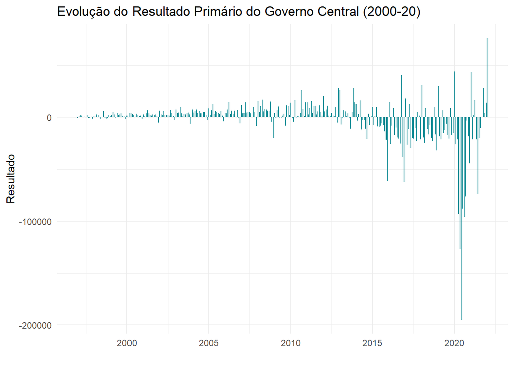

```r
primario_tratado %>%
  ggplot() +
  geom_col(aes(x = mes, y = resultado_primario), fill = "#1c9099", size = 0.5) +
  labs(title = "Evolução do Resultado Primário do Governo Central (2000-20)") +
  xlab(" ") +
  ylab("Resultado") +
  theme_minimal()
```

Selecionando dado de interesse

```r
## Para construir as médias móveis precisamos de um objeto do tipo time series
## Logo, filtramos do dataset original apenas a coluna que contém os dados do resultado primário

dados_serie <- primario_tratado %>%
  select(resultado_primario)
```

Transformando em time-series para `resultado_primario`

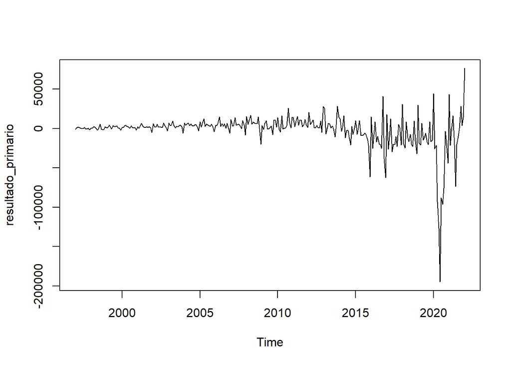

```r
serie_primario <- ts(dados_serie, start = c(1997,1), end = c(2022,1), frequency = 12)
plot(serie_primario)
```

```r
## O prâmetro frequency = 12 faz com que o R retorne uma série temporal mensal com as datas de inicio e fim especificadas em start e end
```